# Evolutionary Rates & Selection Strength

2022-04-08

This vignette explains how to extract evolutionary rate parameters estimated from relaxed clock Bayesian inference analyses produced by the program [Mr. Bayes](https://nbisweden.github.io/MrBayes/). It also shows how to use evolutionary rate based inference of selection strength (or mode) adapted to clock-based rates, as introduced by Simões and Pierce (2021).

## Evolutionary Rates Statistics and Plots

In this section, we will extract evolutionary rate parameters from each node from a Bayesian clock (time-calibrate) summary tree produced by [Mr. Bayes](https://nbisweden.github.io/MrBayes/). The functions below will store them in a data frame, produce summary statistics tables, and create different plots showing how rates are distributed across morphological partitions and clades.

Load the **EvoPhylo** package

```r
library(EvoPhylo)
library(ggtree)
```

```r
library(ggplot2)
```

### 1. Get rates from the clock tree and create a rate table

First, import a Bayesian clock tree using treeio’s function `read.mrbayes` (= `read.beast`), or using one of the example trees provided.

Subsequently, using `get_clockrate_table`, users can extract mean or median rate values for each node in the summary tree that were annotated by [Mr. Bayes](https://nbisweden.github.io/MrBayes/) when creating the summary tree with [Mr. Bayes](https://nbisweden.github.io/MrBayes/) “sumt” command. These mean or median rate values are calculated by [Mr. Bayes](https://nbisweden.github.io/MrBayes/) taking into account all trees from the posterior sample. This works for any summary tree produced by [Mr. Bayes](https://nbisweden.github.io/MrBayes/): a majority rule consensus or the fully resolved maximum compatible tree (the latter is used in the examples here).

Please note that analyses must have reached the stationarity phase and independent runs converging for the summary statistics in each node to be meaningful summaries of the posterior sample.

```r
## Import summary tree with three clock partitions produced by Mr. Bayes (.t or .tre files) from your local directory
tree3p<-treeio::read.mrbayes("examples/MultiClockTree/Tree3p.t")

#OR from example data file
data(tree3p)

## Get table of clock rates with summary stats for each node in the tree for each relaxed clock partition
RateTable_Medians_no_clades <- get_clockrate_table(tree3p, summary = "median")
RateTable_Means_no_clades <- get_clockrate_table(tree3p, summary = "mean")
```

### 2. Export the rate table

This is a necessary step to subsequently open the rate table spreadsheet locally (e.g., using Microsoft Office Excel) and customize the table with clade names associated with with each node in the tree for downstream analysis. To visualize the node values in the tree, you can use ggtree.

```r
## Export the rate tables
write.csv(RateTable_Medians_no_clades, file="RateTable_Medians.csv")
write.csv(RateTable_Means_no_clades, file="RateTable_Means.csv")
```

### 3. Plot tree node labels

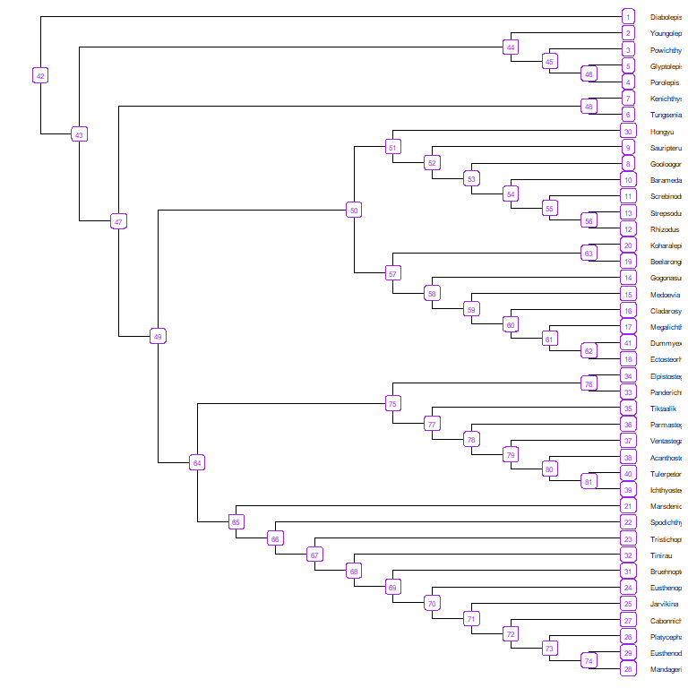

```r
## Plot tree node labels
tree_nodes<-ggtree::ggtree(tree3p, layout = "rectangular", ladderize=TRUE, right=TRUE,
                 branch.length="none", size = 0.05)+
  geom_tiplab(size=2, linesize = 0.01, color="black",  offset = 0.5)+
  geom_label(aes(label=node), size=2, color="purple", position = "dodge")
tree_nodes
```

```r
##(NOT RUN)
## Save your plot to your working directory as a PDF
#ggplot2::ggsave    ("Tree_nodes.pdf", width=10, height=10)
```

### 4. Get summary statistics table and plots

Import the rate table with clade membership (new “clade” column added) and obtain summary statistics table and plots for each clade by clock using `clockrate_summary`.

```r
## Import rate table with clade membership (new "clade" column added) from your local directory
rate_table_clades_medians<- read.csv("examples/MultiClockTree/RateTable_Medians_Clades.csv", header = TRUE)

#OR from example data file
data(rate_table_clades_medians)

head(rate_table_clades_medians)
```

```
##         clade nodes   rates1   rates2   rates3
## 1 Dipnomorpha     1 0.927276 0.958621 0.984651
## 2 Dipnomorpha     2 1.039289 0.757550 0.899578
## 3 Dipnomorpha     3 1.151933 0.627024 0.795243
## 4 Dipnomorpha     4 1.189229 0.451265 0.693551
## 5 Dipnomorpha     5 1.188293 0.446332 0.693501
## 6       Other     6 0.649204 0.694196 0.656767
```

```r
## Get summary statistics table for each clade by clock
clockrate_summary(rate_table_clades_medians, "Sum_RateTable_Medians.csv", digits=3)
```

Rate table summary statistics

| clade | clock | n | mean | sd | min | Q1 | median | Q3 | max |
| --- | --- | --- | --- | --- | --- | --- | --- | --- | --- |
| Dipnomorpha | 1 | 8 | 1.08 | 0.10 | 0.93 | 1.01 | 1.07 | 1.16 | 1.19 |
| Elpisostegalia | 1 | 14 | 1.58 | 0.22 | 1.11 | 1.41 | 1.65 | 1.78 | 1.80 |
| Osteolepididae | 1 | 11 | 0.60 | 0.25 | 0.15 | 0.43 | 0.77 | 0.79 | 0.84 |
| Rhizodontidae | 1 | 14 | 0.54 | 0.30 | 0.01 | 0.31 | 0.64 | 0.80 | 0.85 |
| Tristichopteridae | 1 | 21 | 0.69 | 0.03 | 0.59 | 0.67 | 0.69 | 0.70 | 0.75 |
| Other | 1 | 11 | 0.87 | 0.36 | 0.52 | 0.68 | 0.77 | 0.94 | 1.79 |
| Dipnomorpha | 2 | 8 | 0.72 | 0.21 | 0.45 | 0.58 | 0.73 | 0.89 | 0.98 |
| Elpisostegalia | 2 | 14 | 1.31 | 0.09 | 1.00 | 1.31 | 1.32 | 1.37 | 1.38 |
| Osteolepididae | 2 | 11 | 0.32 | 0.15 | 0.05 | 0.25 | 0.35 | 0.42 | 0.50 |
| Rhizodontidae | 2 | 14 | 0.30 | 0.18 | 0.01 | 0.15 | 0.35 | 0.42 | 0.53 |
| Tristichopteridae | 2 | 21 | 0.31 | 0.06 | 0.24 | 0.29 | 0.29 | 0.31 | 0.53 |
| Other | 2 | 11 | 0.73 | 0.25 | 0.37 | 0.59 | 0.69 | 0.77 | 1.30 |
| Dipnomorpha | 3 | 8 | 0.85 | 0.12 | 0.69 | 0.77 | 0.87 | 0.95 | 0.99 |
| Elpisostegalia | 3 | 14 | 0.80 | 0.15 | 0.60 | 0.65 | 0.85 | 0.94 | 0.95 |
| Osteolepididae | 3 | 11 | 0.28 | 0.13 | 0.06 | 0.23 | 0.26 | 0.39 | 0.48 |
| Rhizodontidae | 3 | 14 | 0.29 | 0.17 | 0.01 | 0.17 | 0.35 | 0.40 | 0.49 |
| Tristichopteridae | 3 | 21 | 0.49 | 0.10 | 0.32 | 0.39 | 0.51 | 0.57 | 0.62 |
| Other | 3 | 11 | 0.72 | 0.16 | 0.45 | 0.63 | 0.69 | 0.80 | 1.00 |

### 5. Plot rates by clock partition and clade

Plot distributions of rates by clock partition and clade with `clockrate_dens_plot`.

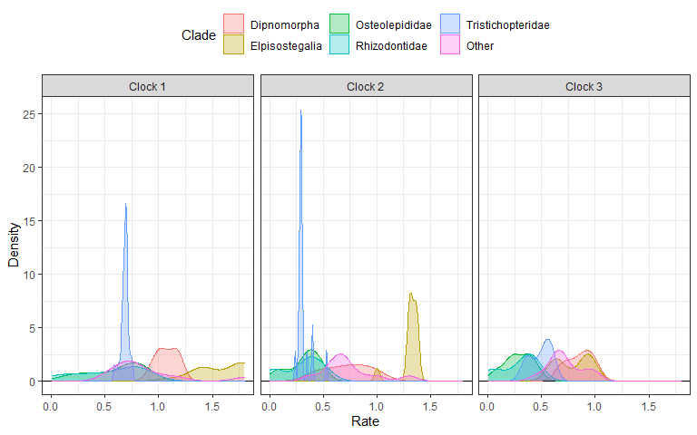

```r
## Overlapping plots
clockrate_dens_plot(rate_table_clades_medians, stack = FALSE, nrow = 1, scales = "fixed")
```

Sometimes using stacked plots provides a better visualization as it avoids overlapping distributions

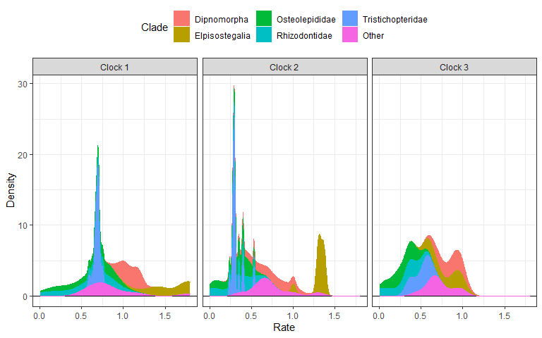

```r
## Stacked plots
clockrate_dens_plot(rate_table_clades_medians, stack = TRUE, nrow = 1, scales = "fixed")
```

It is also possible to append the extra `ggplot`layers, such as for changing the color scale

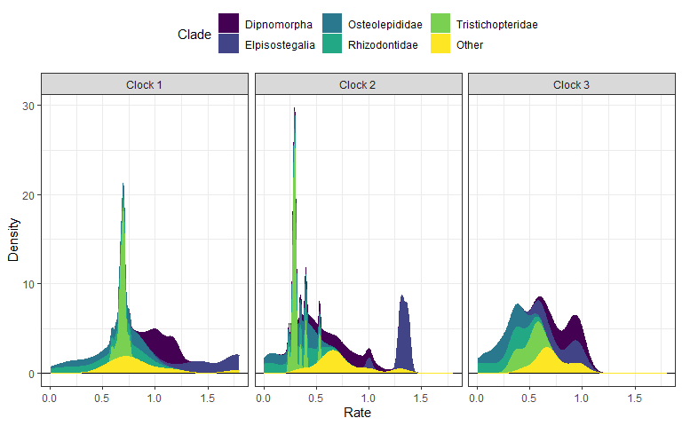

```r
## Stacked plots with viridis color scale
clockrate_dens_plot(rate_table_clades_medians, stack = TRUE, nrow = 1, scales = "fixed")+
    ggplot2::scale_color_viridis_d() +
    ggplot2::scale_fill_viridis_d()
```